# Projet Classification IA vs Humain

Ryane SID IDRIS - Yacine OUALIKEN - Sofiane MOUHOUB

12/02/2026

# 1. Introduction

L’objectif de ce projet est de développer un système capable de distinguer les textes rédigés par des humains de ceux générés par une Intelligence Artificielle. Ce défi repose sur l’hypothèse qu’il existe des caractéristiques linguistiques et stylométriques nuancées propres à chaque classe

# 2. Chargement et Exploration des Données

D’abord, nous commençons par charger les librairies nécessaires.

```r
library(tidyverse)
library(quanteda)
library(quanteda.textstats)
library(readr)
```

# 2.1 Import et fusion des datasets

Nous disposons de quatre fichiers CSV (train_drcat_01 à 04) que nous fusionnons pour obtenir un fichier d’entraînement unique

```r
# Liste des fichiers d'entraînement
files <- c("train_drcat_01.csv", "train_drcat_02.csv", "train_drcat_03.csv", "train_drcat_04.csv")

# Lecture et fusion
full_dataset <- lapply(files, read_csv) %>% bind_rows()

# Nettoyage des textes vides
full_dataset <- full_dataset %>% filter(!is.na(text))

# Affichage des dimensions
cat("Dimensions du dataset fusionné :", dim(full_dataset))
```

```
## Dimensions du dataset fusionné : 159456 6
```

## 3 Analyse Exploratoire des Données (EDA)

Il est crucial d’observer si nos classes sont équilibrées. Un déséquilibre entre le nombre de textes humains et IA pourrait influencer la précision de notre modèle final.

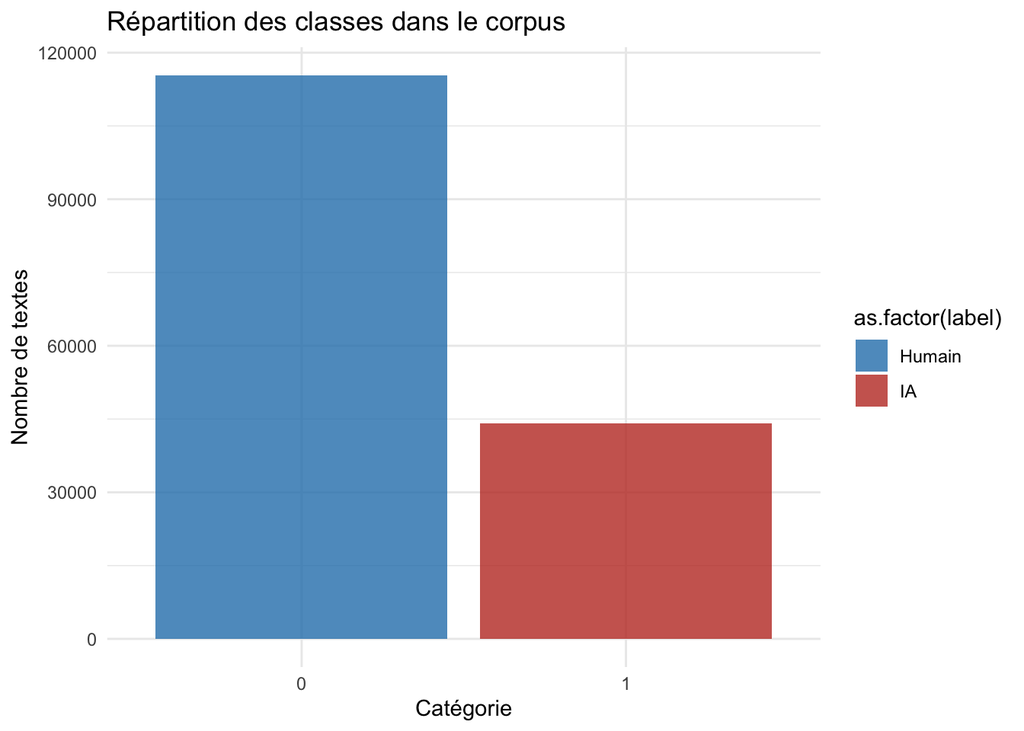

```r
# Visualisation de la distribution des labels (0: Humain, 1: IA)
ggplot(full_dataset, aes(x = as.factor(label), fill = as.factor(label))) +
  geom_bar(alpha = 0.8) +
  scale_fill_manual(values = c("#2980b9", "#c0392b"), labels = c("Humain", "IA")) +
  labs(title = "Répartition des classes dans le corpus", x = "Catégorie", y = "Nombre de textes") +
  theme_minimal()
```

## 4. Extraction des Caractéristiques Stylométriques

Nous extrayons des métriques qui capturent le “style” de l’auteur, comme la variabilité de la longueur des phrases et la densité de ponctuation.

```r
# Calcul des métriques structurelles
data_features <- full_dataset %>%
  mutate(
    word_count = str_count(text, "\\w+"),
    # Écart-type de la longueur des phrases pour mesurer la variabilité
    sentence_var = sapply(str_split(text, "[.!?]"), function(x) sd(nchar(x), na.rm = TRUE)),
    # Ratio de ponctuation par mot
    punc_ratio = str_count(text, "[:punct:]") / word_count
  )

# Remplacement des NA par 0 (pour les textes d'une seule phrase)
data_features$sentence_var[is.na(data_features$sentence_var)] <- 0
```

## 5.Analyse de la Lisibilité (Score de Flesch)

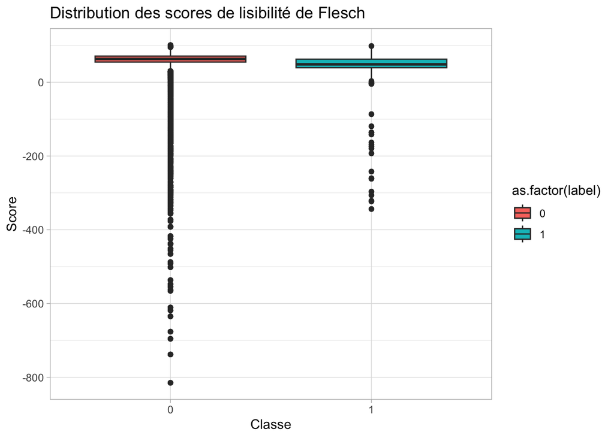

```r
# Création du corpus pour l'analyse textuelle
text_corpus <- corpus(full_dataset$text)

# Calcul du score de Flesch Reading Ease
readability_stats <- textstat_readability(text_corpus, measure = "Flesch")
data_features$flesch_score <- readability_stats$Flesch

# Boxplot pour comparer les deux classes
ggplot(data_features, aes(x = as.factor(label), y = flesch_score, fill = as.factor(label))) +
  geom_boxplot() +
  labs(title = "Distribution des scores de lisibilité de Flesch", x = "Classe", y = "Score") +
  theme_light()
```

Le score de Flesch est utilisé ici comme indicateur de la perplexité : une lisibilité très fluide et constante est souvent corrélée à une faible perplexité typique des LLM.

## 6.Vectorisation et Préparation pour l’AFD

Nous transformons le texte en une matrice TF-IDF de n-grammes pour l’Étudiant 2.

```r
# Transformation en matrice de termes (DFM)
dfm_final <- tokens(text_corpus, remove_punc = TRUE, remove_numbers = TRUE) %>%
  tokens_remove(stopwords("en")) %>%
  tokens_ngrams(n = 1:2) %>%
  dfm() %>%
  dfm_trim(min_termfreq = 20) %>%
  dfm_tfidf()

# Affichage des dimensions de la matrice
dim(dfm_final)
```

```
## [1] 159456 221422
```

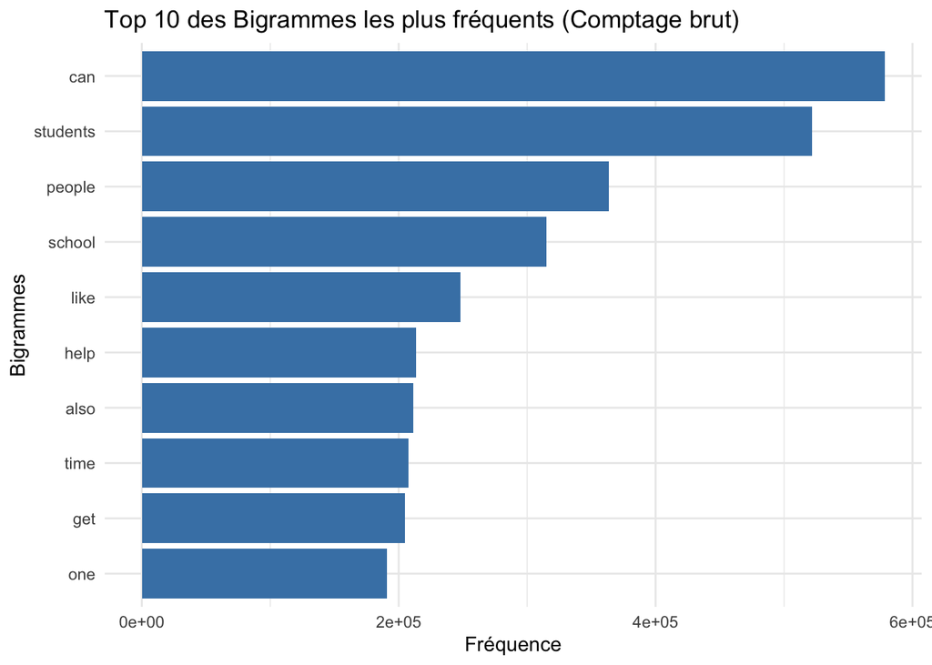

```r
# 1. On crée une DFM de COMPTAGE (sans TF-IDF) pour le graphique
dfm_counts <- tokens(text_corpus, remove_punc = TRUE, remove_numbers = TRUE) %>%
  tokens_remove(stopwords("en")) %>%
  tokens_ngrams(n = 1:2) %>%
  dfm()

# 2. Extraction des fréquences à partir de cette matrice de comptage
freq_words <- textstat_frequency(dfm_counts, n = 10)

# 3. Graphique des fréquences
ggplot(freq_words, aes(x = reorder(feature, frequency), y = frequency)) +
  geom_col(fill = "steelblue") +
  coord_flip() +
  labs(title = "Top 10 des Bigrammes les plus fréquents (Comptage brut)",
       x = "Bigrammes",
       y = "Fréquence") +
  theme_minimal()
```

# 8.1 Fondements Mathématiques de l’AFD

L’objectif de l’AFD est de trouver la meilleure projection pour séparer les classes. Contrairement à une simple réduction de dimension (comme l’ACP) qui conserve la variance globale, l’AFD cherche à discriminer.

Concrètement, on cherche un axe w qui maximise le ratio de Fisher : J(w)=(w^T Sb w)/(w^T Sw w)

L’idée est qu’on veut maximiser le numérateur (Sb, la distance entre les centres des groupes) tout en minimisant le dénominateur (Sw, la dispersion à l’intérieur des groupes). En clair, on veut que les classes soient le plus loin possible l’une de l’autre, tout en restant compactes pour ne pas se mélanger.

# 8.2. Réduction de Dimension par Analyse Factorielle Discriminante (AFD)

Nous passons maintenant à l’étape de projection. L’objectif est de combiner les caractéristiques stylométriques (longueur de phrase, ponctuation) avec les n-grammes les plus fréquents pour construire un espace réduit discriminant.

```r
library(MASS)

#Préparation intelligente de la matrice

dfm_reduced <- dfm_trim(dfm_final, min_termfreq = 50, termfreq_type = "rank")

# Conversion propre en dataframe compatible avec l'AFD
data_tfidf <- convert(dfm_reduced, to = "data.frame")

# Nettoyage des noms de colonnes (ex: "of the" devient "of.the") pour éviter les erreurs R
colnames(data_tfidf) <- make.names(colnames(data_tfidf))

#Fusion des données

dataset_complete <- cbind(
  data_features %>% dplyr::select(label, sentence_var, punc_ratio, flesch_score),
  data_tfidf %>% dplyr::select(-doc_id)
)
dataset_complete <- dataset_complete[, sapply(dataset_complete, function(v) var(v, na.rm=TRUE) != 0)]

#Calcul de l'AFD

# On applique l'AFD sur l'ensemble des variables
afd_model <- lda(label ~ ., data = dataset_complete, na.action = na.omit)

# Projection des données sur le nouvel axe discriminant (LD1)
prediction_afd <- predict(afd_model, dataset_complete)

dataset_for_s3 <- dataset_complete
dataset_for_s3$lda_score <- prediction_afd$x[,1]

# Sauvegarde pour la suite
write.csv(dataset_for_s3, "dataset_reduced_final.csv", row.names = FALSE)

# Affichage de la part de variance expliquée (informatif)
prop_trace <- afd_model$svd^2 / sum(afd_model$svd^2)
cat("Variance expliquée par l'axe LD1 :", round(prop_trace[1]*100, 2), "%")
```

```
## Variance expliquée par l'axe LD1 : 100 %
```

# 9. Visualisation de la Séparation

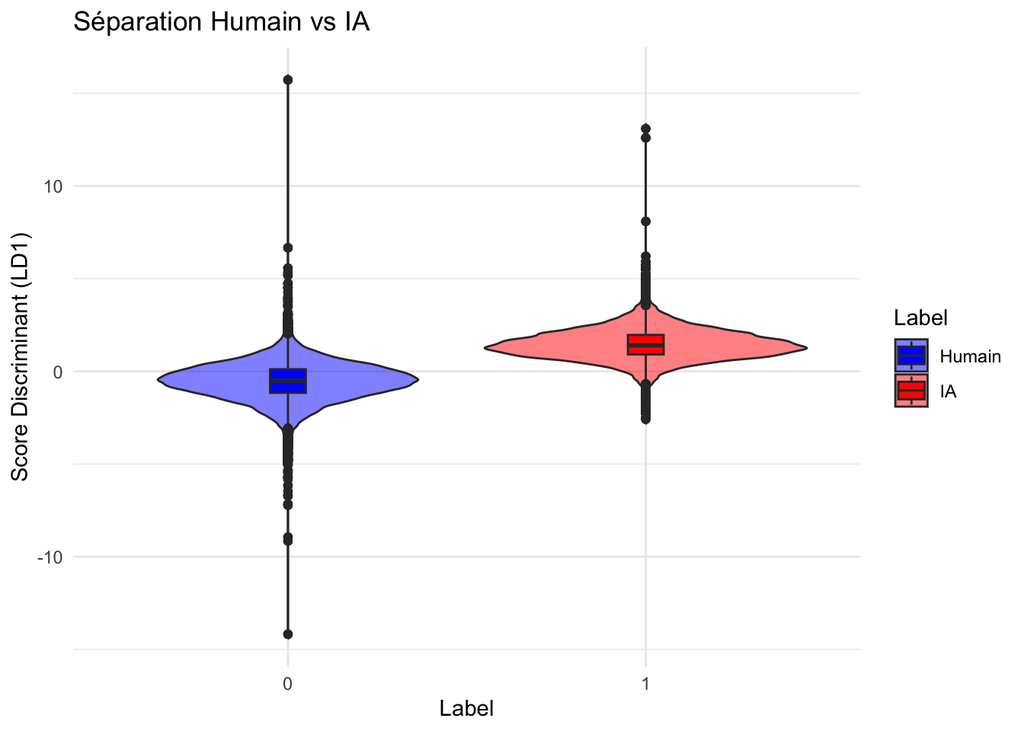

```r
plot_data <- data.frame(LD1 = dataset_for_s3$lda_score, Label = as.factor(dataset_for_s3$label))

ggplot(plot_data, aes(x = Label, y = LD1, fill = Label)) +
  geom_violin(trim = FALSE, alpha = 0.5) +
  geom_boxplot(width = 0.1) +
  scale_fill_manual(values = c("blue", "red"), labels = c("Humain", "IA")) +
  labs(title = "Séparation Humain vs IA",
       y = "Score Discriminant (LD1)") +
  theme_minimal()
```

Le graphique montre une séparation nette : la distribution des textes Humains (en bleu) est bien distincte de celle des textes IA (en rouge) sur l’axe vertical. Ce faible chevauchement confirme que notre score ‘LD1’ arrive bien à capturer les différences de style entre les deux groupes.

# 10. Modélisation Prédictive : Approche Bayésienne

Suite à la réduction de dimension opérée par l’Analyse Factorielle Discriminante (AFD), nous disposons désormais d’un indicateur synthétique fort (le score LD1) combiné aux métriques stylométriques.

Pour la classification finale, nous avons opté pour un **Classifieur Naïf Bayésien**. Ce choix se justifie par la nature probabiliste de notre problématique (estimer la probabilité qu’un texte soit une IA) et par sa robustesse sur des jeux de données où les variables sont décorrélées (ce qui est le cas grâce à l’AFD).

## 10.1 Protocole d’Entraînement

Nous appliquons une **validation croisée stratifiée (10-fold Cross-Validation)**. Cette méthode rigoureuse nous assure que les performances du modèle ne sont pas dues au hasard d’un découpage unique train/test.

```r
# Chargement des paquets requis pour la modélisation
if(!require(e1071)) install.packages("e1071")
if(!require(caret)) install.packages("caret")
if(!require(pROC)) install.packages("pROC")
if(!require(DescTools)) install.packages("DescTools")

library(caret)
library(pROC)
library(DescTools)

# 1. Chargement et préparation des données finales
  donnees_finales <- read.csv("dataset_reduced_final.csv")

# Conversion de la cible en facteurs explicites (Requis par Caret)
# On s'assure que 0 = Humain et 1 = IA
donnees_finales$label <- factor(donnees_finales$label,
                                levels = c(0, 1),
                                labels = c("Humain", "IA"))

# 2. Configuration du contrôle de l'entraînement
ctrl_validation <- trainControl(
  method = "cv",              # Cross-Validation
  number = 10,                # 10 folds
  savePredictions = "final",  # Sauvegarder les prédictions pour l'analyse
  classProbs = TRUE,          # Calculer les probabilités
  summaryFunction = twoClassSummary # Pour obtenir le ROC/AUC
)

# 3. Entraînement du Modèle
set.seed(2026)
modele_bayes <- train(
  label ~ lda_score + sentence_var + punc_ratio + flesch_score,
  data = donnees_finales,
  method = "naive_bayes",
  trControl = ctrl_validation,
  metric = "ROC"
)

# Résumé succinct du modèle
print(modele_bayes)
```

```
## Naive Bayes
##
## 159456 samples
##      4 predictor
##      2 classes: 'Humain', 'IA'
##
## No pre-processing
## Resampling: Cross-Validated (10 fold)
## Summary of sample sizes: 143511, 143510, 143511, 143509, 143511, 143510, ...
## Resampling results across tuning parameters:
##
##   usekernel  ROC        Sens       Spec
##   FALSE      0.9283622  0.8232413  0.9071546
##    TRUE      0.9608566  0.9649742  0.7398601
##
## Tuning parameter 'laplace' was held constant at a value of 0
## Tuning
##  parameter 'adjust' was held constant at a value of 1
## ROC was used to select the optimal model using the largest value.
## The final values used for the model were laplace = 0, usekernel = TRUE
##  and adjust = 1.
```

# 10.2 Évaluation des Performances

Nous analysons la Matrice de Confusion pour vérifier l’équilibre entre Faux Positifs et Faux Négatifs, ainsi que l’aire sous la courbe ROC (AUC).

```r
# Extraction des prédictions
resultats_preds <- modele_bayes$pred

# Matrice de Confusion
matrice_conf <- confusionMatrix(resultats_preds$pred, resultats_preds$obs, mode = "everything")

# Calcul de l'AUC et Préparation ROC
obs_num <- ifelse(resultats_preds$obs == "IA", 1, 0)
prob_ia <- resultats_preds$IA
obj_roc <- roc(obs_num, prob_ia, quiet = TRUE)
auc_score <- auc(obj_roc)

# Score de Brier
brier_score <- BrierScore(obs_num, prob_ia)

# Affichage des Résultats
cat("SYNTHÈSE DES PERFORMANCES\n")
```

```
## SYNTHÈSE DES PERFORMANCES
```

```r
cat("Exactitude (Accuracy)      :", round(matrice_conf$overall["Accuracy"]*100, 2), "%\n")
```

```
## Exactitude (Accuracy)      : 90.27 %
```

```r
cat("Sensibilité (Détection IA) :", round(matrice_conf$byClass["Sensitivity"]*100, 2), "%\n")
```

[output not shown]

```r
cat("Spécificité (Rejet Humain) :", round(matrice_conf$byClass["Specificity"]*100, 2), "%\n")
```

[output not shown]

```r
cat("AUC (Discrimination)       :", round(auc_score, 4), "\n")
```

```
## AUC (Discrimination)       : 0.9608
```

```r
cat("Score de Brier (Fiabilité) :", round(brier_score, 4), "\n")
```

```
## Score de Brier (Fiabilité) : 0.0726
```

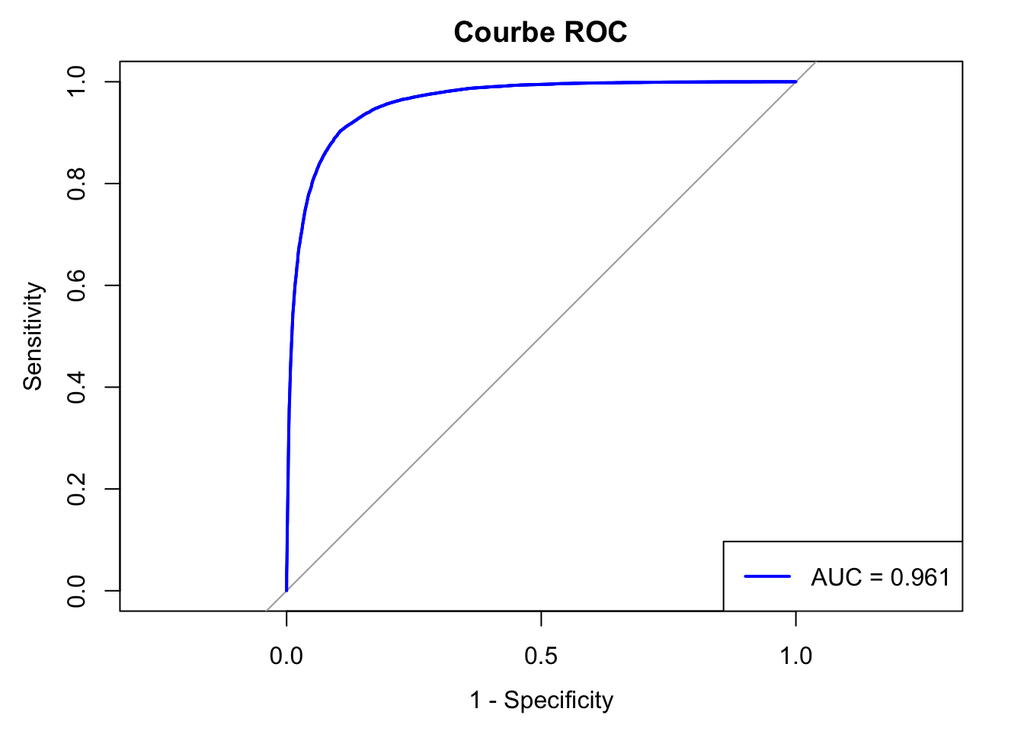

```r
# Visualisation de la Courbe ROC
plot(obj_roc,
     col = "blue",
     lwd = 2,
     main = "Courbe ROC",
     legacy.axes = TRUE)

# Légende
legend("bottomright", legend = paste("AUC =", round(auc_score, 3)), col = "blue", lwd = 2)
```

Enfin, le Score de Brier de 0.07 (très proche de 0) indique que le modèle est fiable : ses prédictions sont tranchées et non hésitantes.

# 11. Conclusion

Ce projet nous a permis de voir que combiner l’analyse du style (longueur des phrases, ponctuation) et les probabilités est une méthode très efficace pour repérer les textes générés par IA.

L’étape la plus importante a été l’utilisation de l’Analyse Factorielle Discriminante (AFD). Au lieu de se perdre avec des milliers de variables (les mots et le style), l’AFD a résumé toute l’information en un seul score (LD1). C’est grâce à cette simplification que notre modèle Naïf Bayésien a pu atteindre une excellente performance (AUC de 0.96).

# 12. Pistes d’Amélioration (Travaux Futurs)

Pour aller plus loin et détecter les nouvelles IA (qui imitent de mieux en mieux les humains), nous pourrions explorer plusieurs pistes que nous n’avons pas pu coder par manque de temps :

-Comprendre le sens des phrases Nous avons utilisé la méthode TF-IDF, qui compte juste la présence des mots. Remplacer cela par des modèles comme BERT qu’on a déja utilisé dans un précédent projet (par exemple dans le projet Trading/IA que j’ai fait l’année dernière (Ryane SID IDRIS) permettrait d’analyser le sens et la logique du texte. Souvent, l’IA fait des phrases correctes grammaticalement mais qui manquent de fond, ce que BERT pourrait repérer.

-Séparer des groupes mélangés (Kernel LDA) L’AFD classique trace une ligne droite pour séparer les groupes. Si les textes humains et IA finissent par trop se ressembler, il faudrait utiliser le “Kernel Trick” (KDA) pour tracer des frontières courbes et plus complexes.